# A_B Testing Lesson Notes

## A/B Testing - Lesson Notes

You need a clear control and clear metrics to run a trustworthy A/B Test.

### Process

1. **Decide on your change.** Changing the color of the 'start now' button from orange to pink.
2. **Form your hypothesis.** Changing the 'start now' button from orange to pink will increase how many students explore the courses.
3. **Pick a metric.** Total # of courses completed, or # of clicks, click-through-rate (clicks/# of page views), or click-through-probability (unique clicks/unique visitors to page)
4. **Update hypothesis** Changing the 'start now' button from orange to pink will increase the click-through-probability of the button.

> Rate to measure usability, probability when you want to measure the total impact.

## Statistics for A/B Testing

Binomial Distribution - A binomial experiment is a statistical experiment that has the following properties: The experiment consists of n repeated trials. Each trial can result in just two possible outcomes. We call one of these outcomes a success and the other, a failure. The probability of success, denoted by P, is the same on every trial.

Confidence Interval - 95% commonly used, this means that if the experiment is repeated over and over you would expect the interval constructed around the sample mean to cover the true value in the population 95% of the time.

Hypothesis Test: Null hypothesis for the example - there was no change, Pcont = Pexp Alternative Hypothesis for the example - Pexp - Pcont != 0

Practical Significance - substantive significance is the same thing, is it practical to make the change.

```python
from IPython.display import Image
```

[figure not shown]

```python
Image('capture.png')
```

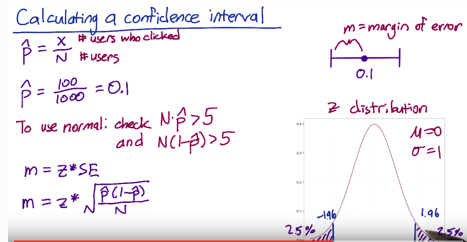

```python
Image('capture1.png')
```

[figure not shown]

```python
Image('capture2.png')
```

[figure not shown]

```python
Image('capture3.png')
```

Design the experiment - statistical power, enough observations to make a significant conclusion

http://www.evanmiller.org/ab-testing/sample-size.html <- calculate sample size needed to have a statistically significant test

## Metrics for Experiments

One sentence that everyone will understand (active users, click through probability)

Best to keep metrics separate, not combine them.